# Naive Bayes Classifier

## Discovering Patterns in the Russian Housing Market for Analysis and Prediction

### 3804ICT Assignment Part I | Naïve Bayes Classifier | Trimester 2, 2019

Joshua Russell (s5057545) | joshua.russell2@griffithuni.edu.au

Joshua Mitchell (s5055278) | joshua.mitchell4@griffithuni.edu.au

Hayden Flatley (s5088623) | hayden.flatley@griffithuni.edu.au

### 1. Introduction

#### 1.1. Aim

This investigation aims to develop a classifier for predicting the sub-areas (districts) of properties in Russia. Developing a model to predict a Russian district based upon property and neighbourhood attributes will provide home buyers with a novel way of finding a district that is ideal for themselves and/or their families. Such a model could be used in an application or on a website, allowing home buyers to specify their ideal property and neighbourhood features and receive recommended districts to rent or buy in. We will use a probabilistic classifier based on Bayes’ theorem, known as the Naïve Bayes Classifier, for this task of classification. We introduce the Naïve Bayes Classifier below.

#### 1.2. Naïve Bayes Classifier

The Naïve Bayes Classifier is a probabilistic classifier based on Bayes' theorem. Classifiers are models that take a data sample $\boldsymbol{x} = (x_1, x_2, x_3, ..., x_n)$ as input and output a predicted class label $\hat{y}$. For example, in our task of classifying Russian districts based upon property and neighbourhood attributes, the input to the classifier would be an attribute/feature vector, $\boldsymbol{x}\in{X}$, containing values such as the number of rooms in the property, the distance to the closest train station in kilometres, whether the property is in a good condition or not etc. and the output of the classifier, $\hat{y}\in{Y}$, would be an integer that represents one of the 145 Russian districts in the dataset. Here, $X$ is the set of data samples in our dataset, and $Y$ is the finite set of integer class labels that represent the names of the Russian districts within our dataset. Formally, we can represent this kind of classifier as a function $f$:

$$\hat{y} = f(\boldsymbol{x}) $$

In the case of probabilistic classifiers, rather than the classifier being a function that predicts a single class given a particular input, the classifier is instead a conditional distribution $P(Y|X)$ that provides a probability to all classes $y\in{Y}$ given an input $\boldsymbol{x}\in{X}$. In order to determine which class from $Y$ should be our predicted class $\hat{y}$, we can simply choose the class that is "most probable" given the input $\boldsymbol{x}\in{X}$. The "most probable" class given our probability distribution $P(Y|X)$ is the class $y$ which has the largest probability given $\boldsymbol{x}\in{X}$:

$$\hat{y} = argmax_y P(Y=y|X)$$

We have now clarified what it means for the Naïve Bayes Classifier to be a probabilistic classifier. The next concept to address is the theorem that the classifier is based upon, Bayes' theorem. Bayes' theorem states that the probability of a hypothesis $H$ given evidence $E$, $P(H|E)$, is equal to the probability of observing the evidence given the hypothesis $P(E|H)$ multiplied by the probability of the hypothesis $P(H)$, all divided by the probability of observing the evidence $P(E)$:

$$P(H|E) = \frac{P(E|H)P(H)}{P(E)}$$

If we slightly rearrange the formula, we are able to see that Bayes' theorem allows us to update our belief about a particular hypothesis ($P(H)$) based upon new evidence ($\frac{P(E|H)}{P(E)}$):

$$P(H|E) = \frac{P(E|H)}{P(E)}P(H)$$

For example, say that we are shown an image of a property in Moscow by a Russian man and we would like to determine how likely it is that the given property is within the Moscow district Perovo. We can start by thinking about how likely it is for a property to be within the district Perovo. After researching the district online, we find that it is a rather populated district, housing approximately 30% of the population within Moscow. As a result, we decide to quantify our research observations in a hypothesis that states that there is a 30% chance that the given property is in Perovo, or $P(Perovo) = 0.3$. Some time goes by, and the Russian man tells us that the property in the image is his home and that is was snowing there yesterday as he was leaving for Australia. We look online and find that it snowed in Perovo yesterday. Therefore, the probability that it snowed yesterday given that the district was indeed Perovo is $P(Snowed Yesterday|Perovo) = 1.0$. However, it also snowed in 5 of the 11 other districts, and thus the probability that it snowed yesterday in all of Moscow is $P(Snowed Yesterday) = 0.5$. This information is additional evidence we can use to refine, or update, our hypothesis about the probability that the property is within the district Perovo. Using Bayes' theorem, we can represent the probability of the property being within the district Perovo given that we know it snowed yesterday as follows:

$$P(Perovo|Snowed Yesterday) = \frac{P(Snowed Yesterday|Perovo)}{P(Snowed Yesterday)}P(Perovo)$$

Substituting in the probabilities from above we get:

$$P(Perovo|Snowed Yesterday) = \frac{1.0}{0.5}0.3 = 0.6$$

Thus, by receiving additional evidence about our hypothesis we were able to update our belief about the probability of the property being with the district Perovo from 30% to 60%. This is exactly what we would like to do within the task of classification. For each class (or hypothesis) $y\in{Y}$, we want to use the feature vector (or evidence) $\boldsymbol{x}\in{X}$ to update our belief about what class $y$ is most probable given the features $\boldsymbol{x}$. This theory is what the Naïve Bayes Classifier is based upon.

For the task of classification, if we want to express the probability that a feature vector $\boldsymbol{x}\in{X}$ belongs to a certain class $y\in{Y}$, we can do so using Bayes' theorem:

$$P(y|\boldsymbol{x}) = \frac{P(\boldsymbol{x}|y)P(y)}{P(\boldsymbol{x})}$$

where $\boldsymbol{x} = (x_1, x_2, x_3, ..., x_n) $. Our goal in classification is to find the class $y\in{Y}$ that is the most probable class for a given feature vector $\boldsymbol{x}\in{X}$. When comparing the probabilities of various classes using the formula above, we can appreciate that the denominator remains the same among all values of $y\in{Y}$ (since $P(\boldsymbol{x})$ is independent of $y\in{Y}$). Consequently, we can disregard the denominator of the formula and introduce a proportionality for comparing the various classes:

$$P(y|\boldsymbol{x}) \propto P(\boldsymbol{x}|y)P(y)$$

We can simplify this equation with rules from conditional probability, by letting $P(\boldsymbol{x}|y)P(y)$ be equal to $P(\boldsymbol{x}, y)$, and by substituting $(x_1, x_2, x_3, ..., x_n)$ for $\boldsymbol{x}$:

$$P(y|x_1, x_2, x_3, ..., x_n) \propto P(x_1, x_2, x_3, ..., x_n, y)$$

Furthermore, we can expand the probability $P(x_1, x_2, x_3, ..., x_n, y)$ using the chain rule to arrive at:

$$P(y|x_1, x_2, x_3, ..., x_n) \propto P(x_1|x_2, ..., x_n, y) \times P(x_2|x_3, ..., x_n, y) \times ... \times P(x_{n-1}|x_n, y) \times P(x_n|y) \times P(y)$$

Once the proportionality is in this form, we are able to see the shortcomings of the "complete" Bayesian approach. In our task of classifying Russian districts based upon property and neighbourhood attributes, we have 291 attributes that we could use to represent each data sample. Therefore, the attribute vector $\boldsymbol{x}$ would be equal to $(x_1, x_2, x_3, ..., x_{291})$. If we were given an arbitrary data sample and tried to calculate one of the probabilities from above, say $P(x_1|x_2, ..., x_n, y)$, then we would need to estimate $P(x_1|x_2, ..., x_{291}, y)$. The problem with estimating this probability is that we need to find data samples in the dataset that have 291 matching attributes with the given attribute vector $\boldsymbol{x}$, while also belonging to a given class $y$. In most cases, there will not be any matching data samples, and as a result, we will not be able to properly estimate the probability of the attribute vector $\boldsymbol{x}$ belonging to each of the classes $y\in{Y}$. The Naïve Bayes Classifier works around this problem by assuming that all the attributes, $x_1, x_2, x_3, ..., x_n$, are independent (i.e. the presence of an attribute value does not affect the values of any other attribute). This is why the classifier is called naïve, as it does not consider dependencies between attributes. It should also be noted that there is another assumption that is implied by assuming independence. This second assumption is that all the attributes are assumed to have an equal effect on the probability that a given data sample belongs to a particular class. Taking these assumptions into consideration, we can change the above equation to the following:

$$P(y|x_1, x_2, x_3, ..., x_n) \propto P(x_1|y) \times P(x_2|y) \times ... \times P(x_{n-1}|y) \times P(x_n|y) \times P(y)$$

Which is equivalent to:

$$P(y|x_1, x_2, x_3, ..., x_n) \propto P(y) \prod_{i = 1}^{n} P(x_i|y)$$

Now that we have a feasible way to compare the probabilities of the classes $y\in{Y}$ given a feature vector $\boldsymbol{x}\in{X}$, we can "classify" (i.e. predict) which class the feature vector or data sample belongs to by finding the class that gives the largest probability:

$$\hat{y} = argmax_y P(y) \prod_{i = 1}^{n} P(x_i|y)$$

The formula above is the essence of the Naïve Bayes Classifier. Another assumption that has not been addressed above is that the Naïve Bayes Classifier assumes that the attributes are categorical. Therefore, estimating a conditional probability such as $P(x_i|y)$ can be done simply by counting the occurrences of the attribute value $x_i$ when the corresponding class was $y$, and dividing this count by the total number of occurrences of the class $y$ in the dataset. However, when attributes take on a numerical value, if we were to treat them as categorical attributes and estimate the conditional probability $P(x_i|y)$ in the same way as described, then we would have a similar problem to what we had before with dependent features (i.e. there would be little, if any, data samples with the same corresponding numerical attribute value to use in the probability calculation because the range of possible values is typically too large). Consequently, there have been methods developed to solve this problem. The simplest solution is to discretise the attribute's range into bins. We explored this method in our *Data Investigation Notebook*, where we discretised the attribute "park_km" (representing the distance from the property to the nearest park in kilometres) into a categorical attribute with values "NEAR", "MODERATE" and "FAR" (based upon ranges that were chosen by ourselves to represent what would be considered nearby, a moderate distance away, or far away). The other approach is to perform probability density estimation on the numerical attribute. In this method, we assume that the attribute's values are sampled from a Gaussian distribution. We then estimate the parameters of the distribution (mean and standard deviation) using maximum likelihood estimation:

$$ mean = \hat{\mu} = \bar{x} = \frac{1}{n}\sum_{i=1}^{n}x_i $$

$$ standard\_deviation = \hat{\sigma} = \sqrt{\frac{1}{n}\sum_{i=1}^{n} (x_i - \bar{x}})^2 $$

Once we have estimated the parameters of the distribution, we can estimate the conditional probability $ P(x_i|y) $ using the following equation:

$$P(x_i|y)=\frac{1}{\sqrt{2\pi\sigma^{2}_y}} exp (-\frac{(x_i - \mu_y)^2}{2\sigma^{2}_y})$$

In the following investigation we will explore these numerical methods and use the Naïve Bayes Classifier for the task of classifying Russian districts based upon property and neighbourhood attributes.

#### 1.3. References:

- Bayes' Theorem and Conditional Probability. Retrieved 7 September 2019, from https://brilliant.org/wiki/bayes-theorem/
- CrashCourse. (2018). *You know I’m all about that Bayes: Crash Course Statistics #24* [Video]. Retrieved from https://www.youtube.com/watch?v=9TDjifpGj-k&t=205s
- Gandhi, R. (2018). Naive Bayes Classifier. Retrieved 11 September 2019, from https://towardsdatascience.com/naive-bayes-classifier-81d512f50a7c

### 2. Preprocessing

Here we import library modules, load the Russian housing market datasets and preprocess the data for the task of classification with the Naïve Bayes Classifier. The following is a list of the property and neighbourhood attributes that we will use for this task:

- `state` - apartment condition
- `full_sq` - total area in square meters
- `life_sq` - living area in square meters
- `floor` - for apartments, floor of the building
- `ecology` - ecological zone where the house is located
- `material` - wall material
- `max_floor` - number of floors in the building
- `build_year` - year built
- `product_type` - owner-occupier purchase or investment
- `nuclear_reactor_raion` - presence of existing nuclear reactors
- `thermal_power_plant_raion` - presence of thermal power station in district
- `incineration_raion` - presence of incinerators
- `oil_chemistry_raion` - presence of dirty industries
- `radiation_raion` - presence of radioactive waste disposal
- `railroad_terminal_raion` - presence of the railroad terminal in district
- `big_market_raion` - presence of large grocery / wholesale markets
- `detention_facility_raion` - presence of detention centers, prisons
- `railroad_1line` - first line to the railway (100 m)

```python
# Imports
import nltk
import time
import warnings
import numpy as np
import pandas as pd
import seaborn as sns
import matplotlib.pyplot as plt

from tqdm import tqdm
from scipy import stats
from sklearn import metrics
from sklearn import datasets
from sklearn import preprocessing
from sklearn.naive_bayes import GaussianNB, MultinomialNB

# Notebook settings
warnings.filterwarnings("ignore")
```

Known dependencies: `pandas-0.25.1`

To ensure that the Naïve Bayes Classifiers were implemented correctly, we tested them on toy datasets with given solutions. The first dataset, `"categorical"`, is from slide 42 in the 3804ICT Lecture 6 lecture slides. This dataset was used to test the manual implementation of the categorical/multinominal Naïve Bayes Classifier. The second dataset, `"zero_stddev"`, was a customised subset of the `"categorical"` dataset used for testing the manual implementation of the Gaussian Naïve Bayes Classifier. As the name of the dataset implies, this dataset was created to test the case where the maximum likelihood estimation (MLE) of the standard deviation was equal to zero. This occurs when we are trying to calculate the MLE on an attribute that has the same numerical value for all data samples belonging to a particular class. Testing our implementation and the library implementations on this toy dataset allowed us to propose a solution for handling this special case, which lead to an increase in accuracy in comparison to the library implementation.

```python
# Evaluate the implementation of the algorithms on toy datasets
evaluate_implementation = False

# Select the toy dataset to use ("zero_stddev", "categorical")
evaluation_datasets = "zero_stddev"
```

```python
# Load the Russian Housing Market datasets into pandas DataFrames
df_test = pd.read_csv("Data/test.csv")
df_train = pd.read_csv("Data/train.csv")

# Add a 'price_doc' column to the test DataFrame filled with NaN values
df_test = df_test.assign(price_doc=pd.Series([np.nan for i in range(df_test.shape[0])]).values)

# Add an 'identifier' column to the test DataFrame filled with "TEST" string values
df_test = df_test.assign(identifier=pd.Series(["TEST" for i in range(df_test.shape[0])]).values)

# Add an 'identifier' column to the train DataFrame filled with "TRAIN" string values
df_train = df_train.assign(identifier=pd.Series(["TRAIN" for i in range(df_train.shape[0])]).values)

# Concatenate test and train DataFrames
df = pd.concat([df_train, df_test], sort=False, ignore_index=True)

# Concatenate datasets (both training and testing data samples)
print("Complete dataset\n- No. data samples: {}\n- No. of attributes: {}".format(df.shape[0], df.shape[1]))
```

```
Complete dataset
- No. data samples: 38133
- No. of attributes: 293
```

```python
# Define the property and neighbourhood attributes that will be used for classifying the districts of properties
attributes = ["state", "full_sq", "life_sq", "floor", "ecology", "material", "max_floor", "build_year", "product_type",
              "nuclear_reactor_raion", "thermal_power_plant_raion", "incineration_raion", "oil_chemistry_raion",
              "radiation_raion", "railroad_terminal_raion", "big_market_raion", "detention_facility_raion", "railroad_1line"]
```

#### 2.1. Data Cleaning

Preprocessing steps for cleaning noisy data values are taken from our *Part 1: Data Investigation Notebook*.

```python
# Set the properties with `floor` or `max_floor` as null to have values of 1 for `floor` / `max_floor`
df.loc[df.floor.isnull(), 'floor'] = 1
df.loc[df.floor.isnull(), 'max_floor'] = 1

# Set the properties with `floor` greater than `max_floor` to have a `max_floor` equal to that of `floor`
df.loc[(df['floor'] > df['max_floor']), 'max_floor'] = df.loc[(df['floor'] > df['max_floor']), 'floor']

# Drop the data sample with a `state` value of 33
df = df.drop(df[(df.state > 4)].index)

# Set `full_sq` to be equal to `life_sq` in the cases where life_sq > full_sq
df.loc[(df.life_sq > df.full_sq), 'full_sq'] = df[(df.life_sq > df.full_sq)]["life_sq"]

# Drop the data samples with `build year` greater than 2019 or less than 1000
df = df.drop(df[(df.build_year > 2019) | (df.build_year < 1000)].index)

# Drop the remaining data samples that contain NaN values for any of the chosen attributes
df = df.dropna(subset=attributes)

# Display the dataset size after preprocessing
print("Preprocessed dataset\n- No. data samples: {}\n- No. of attributes: {}".format(df.shape[0], df.shape[1]))
```

```
Preprocessed dataset
- No. data samples: 19898
- No. of attributes: 293
```

#### 2.2. Data Transformation and Data Discretization

Here we convert certain attribute values into values that are compatible with the Naïve Bayes Classifier library functions. After examining the number of unique values in each attribute, we defined a rule for determining if a particular attribute is categorical or continuous. The rule is as follows, if the attribute has less than eight unique values or if the attribute's value type is string, then the attribute is categorical and should therefore have its values transformed into a discrete set of numbers.

```python
# Display dataset attribute information
print("{:<30} {:<15} {}".format("Attribute", "Data Type", "No. Unique Values"))
print("{:<30} {:<15} {}".format("---------", "---------", "-----------------"))
for a in attributes + ["sub_area"]:
    print("{:<30} {:<15} {}".format(a, str(df[a].dtype), len(set(df[a]))))
```

```
Attribute                      Data Type       No. Unique Values
---------                      ---------       -----------------
state                          float64         4
full_sq                        float64         1105
life_sq                        float64         829
floor                          float64         40
ecology                        object          5
material                       float64         6
max_floor                      float64         49
build_year                     float64         116
product_type                   object          2
nuclear_reactor_raion          object          2
thermal_power_plant_raion      object          2
incineration_raion             object          2
oil_chemistry_raion            object          2
radiation_raion                object          2
railroad_terminal_raion        object          2
big_market_raion               object          2
detention_facility_raion       object          2
railroad_1line                 object          2
sub_area                       object          145
```

```python
# Convert attribute values into a discrete set of numbers (i.e. ["No", "Yes"] -> [0, 1]).
attribute_encoders = {}
for a in attributes + ["sub_area"]:
    if len(set(df[a])) < 8 or str(df[a].dtype) == "object":
        encoder = preprocessing.LabelEncoder()
        encoder.fit(df[a])
        df[a] = encoder.transform(df[a])
        attribute_encoders[a] = encoder
```

#### 2.3. Training and Test Set Preparation

We select the sub-dataframes which contain only the selected feature vector attributes and the target attribute for our investigation. We then create the training and test sets to be used for training and testing the Naïve Bayes Classifier.

```python
# Testing the implementation of the algorithm
if evaluate_implementation:

    # Categorical dataset
    if evaluation_datasets == "categorical":

        # Define the contents of the dataset
        train_dataset = {"GiveBirth":   [1, 0, 0, 1, 0, 0, 1, 0, 1, 1, 0, 0, 1, 0, 0, 0, 0, 0, 1, 0],
                         "CanFly":      [0, 0, 0, 0, 0, 0, 1, 1, 0, 0, 0, 0, 0, 0, 0, 0, 0, 1, 0, 1],
                         "LiveInWater": [0, 0, 1, 1, 2, 0, 0, 0, 0, 1, 2, 2, 0, 1, 2, 0, 0, 0, 1, 0],
                         "HaveLegs":    [1, 0, 0, 0, 1, 1, 1, 1, 1, 0, 1, 1, 1, 0, 1, 1, 1, 1, 0, 1],
                         "Class":       [1, 0, 0, 1, 0, 0, 1, 0, 1, 0, 0, 0, 1, 0, 0, 0, 1, 0, 1, 0]}
        test_dataset = {"GiveBirth":   [1],
                        "CanFly":      [0],
                        "LiveInWater": [1],
                        "HaveLegs":    [0],
                        "Class":       [1]}

        # Define the attribute names of the dataset
        attributes = ["GiveBirth", "CanFly", "LiveInWater", "HaveLegs"]

        # Select sub-dataframes of relevant attributes for the training and test sets
        categorical_df_train = pd.DataFrame(data=train_dataset)
        categorical_df_test = pd.DataFrame(data=test_dataset)
        x_train = categorical_df_train[attributes].copy()
        y_train = categorical_df_train[["Class"]].copy()
        x_test = categorical_df_test[attributes].copy()
        y_test = categorical_df_test[["Class"]].copy()

    # Zero standard deviation dataset
    elif evaluation_datasets == "zero_stddev":

        # Define the contents of the dataset
        slides_train_dataset = {"GiveBirth":   [1, 0, 0, 1, 0],
                                "CanFly":      [0, 0, 0, 0, 0],
                                "Class":       [1, 0, 0, 1, 0],}
        slides_test_dataset = {"GiveBirth":    [1],
                                "CanFly":      [0],
                                "Class":       [1]}

        # Define the attribute names of the dataset
        attributes = ["GiveBirth", "CanFly"]

        # Select sub-dataframes of relevant attributes for the training and test sets
        slides_df_train = pd.DataFrame(data=slides_train_dataset)
        slides_df_test = pd.DataFrame(data=slides_test_dataset)
        x_train = slides_df_train[attributes].copy()
        y_train = slides_df_train[["Class"]].copy()
        x_test = slides_df_test[attributes].copy()
        y_test = slides_df_test[["Class"]].copy()

# Conducting experimentation/testing on the Russian housing market dataset
else:

    # Define the number of test samples to use
    num_test_samples = 50

    # Split the DataFrame back into training and testing DataFrames
    df_train = df[(df.identifier == "TRAIN")]
    df_test = df[(df.identifier == "TEST")]

    # Select sub-dataframes of relevant attributes for the training and test sets
    x_train = df_train[attributes].copy()
    y_train = df_train[["sub_area"]].copy()
    x_test = df_test[attributes].copy()[:num_test_samples]
    y_test = df_test[["sub_area"]].copy()[:num_test_samples]

# Preprocess the datasets for the manual implementation of the Naïve Bayes Classifier
x_train_manual = x_train.to_numpy()
y_train_manual = y_train.to_numpy().reshape(len(y_train))
x_test_manual = x_test.to_numpy()
y_test_manual = y_test.to_numpy().reshape(len(y_test))

# Define a function to assist with formatting data samples so that they are compatible with the NLTK Naïve Bayes Classifier
def format_nltk_data_sample(x, y, x_names):
    """ Formats a data sample so that it is compatible with the NLTK Naïve Bayes Classifier.

    :param x: A one dimensional array representing a feature vector.
    :param y: A numeric value representing the class of the given feature vector x.
    :param x_names: A one dimensional array of strings containing the names of the features in the dataset.
    :return: A two element tuple containing the formatted feature vector and the corresponding class label for the given
             data sample.
    """

    # Map the feature vector values to "{feature_name}-{feature_value}" (i.e. "build_year-1907.0")
    features = {}
    for i in range(len(x)):
        features["contains({}-{})".format(x_names[i], x[i])] = True

    # Return the formatted data sample
    return (features, str(y))

# Preprocess the datasets for the NLTK Naïve Bayes Classifier
xy_train_nltk = [format_nltk_data_sample(x_train_manual[i], y_train_manual[i], attributes) for i in range(len(y_train_manual))]
x_test_nltk = [format_nltk_data_sample(x_test_manual[i], y_test_manual[i], attributes)[0] for i in range(len(y_test_manual))]
y_test_nltk = [format_nltk_data_sample(x_test_manual[i], y_test_manual[i], attributes)[1] for i in range(len(y_test_manual))]
```

### 3. Library Solutions

We implement the Naïve Bayes Classifier using two Python libraries, Scikit-learn and the Natural Language Toolkit (NLTK). In the Scikit-learn solution, we implement two variants of the classifier. These variants assume different properties about the features. One variant assumes the features follow a Gaussian distribution, and the other assumes the features are categorical/nominal.

#### 3.1. Scikit-learn

```python
def scikit_learn_gaussian_NB(x_train, y_train, x_test):
    """ Scikit-learn Naïve Bayes Gaussian Classifier.

    The Gaussian Classifier assumes that the features follow a Gaussian distribution.

    :param x_train: DataFrame containing the training set feature vectors.
    :param y_train: DataFrame containing the training set class labels.
    :param x_test: DataFrame containing the test set feature vectors.
    :return: Numpy array containing the predicted class labels of the test set feature vectors.
    """

    # Create a Gaussian Naïve Bayes Classifier
    gnb = GaussianNB()

    # Train the model on the training set
    gnb.fit(x_train, np.array(y_train).reshape(y_train.shape[0]))

    # Predict the district class based upon the feature vectors in the test set
    y_pred = gnb.predict(x_test)

    if evaluate_implementation:
        print("Predicted probabilities: {}".format(gnb.predict_proba(x_test)))

    # Return district predictions
    return y_pred
```

```python
def scikit_learn_multinomial_NB(x_train, y_train, x_test, laplace_smoothing):
    """ Scikit-learn Naïve Bayes Multinomial Classifier.

    The Multinomial Classifier assumes that the features are categorical.
    Thus, the probabilities P(x_i|y) are determined through relative frequency counting.

    :param x_train: DataFrame containing the training set feature vectors.
    :param y_train: DataFrame containing the training set class labels.
    :param x_test: DataFrame containing the test set feature vectors.
    :param laplace_smoothing: A Boolean value indicating whether or not to use laplace smoothing when calculating the
                              likelihood.
    :return: Numpy array containing the predicted class labels of the test set feature vectors.
    """

    # Create a Multinomial Naïve Bayes Classifier (Alpha set to 1 for Laplace smoothing, 0 otherwise)
    if laplace_smoothing:
        mnb = MultinomialNB(alpha=1, fit_prior=False)
    else:
        mnb = MultinomialNB(alpha=0, fit_prior=False)

    # Train the model on the training set
    mnb.fit(x_train, np.array(y_train).reshape(y_train.shape[0]))

    # Predict the district class based upon the feature vectors in the test set
    y_pred = mnb.predict(x_test)

    if evaluate_implementation:
        print("Predicted probabilities: {}".format(mnb.predict_proba(x_test)))

    # Return district predictions
    return y_pred
```

#### 3.2. Natural Language Toolkit (NLTK)

```python
def NLTK_multinomial_NB(xy_train_set, x_test_set):
    """ NLTK Naïve Bayes Multinomial Classifier.

    The Multinomial Classifier assumes that the features are categorical.
    Thus, the probabilities P(x_i|y) are determined through relative frequency counting.

    :param x_train: DataFrame containing the training set feature vectors and class labels.
    :param x_test_set: DataFrame containing the test set feature vectors.
    :return: An array containing the predicted class labels of the test set feature vectors.
    """

    # Create a Multinomial Naïve Bayes Classifier and train it on the training set
    classifier = nltk.NaiveBayesClassifier.train(xy_train_set)

    # Predict the district class based upon the feature vectors in the test set
    y_pred = [classifier.classify(x) for x in x_test_set]

    # Return district predictions
    return y_pred
```

### 4. Manual Solution

This section contains our manual implementation of the Naïve Bayes Classifier. We implemented three variants of the classifier which are based upon different feature assumptions. The first variant assumes that the features follow a Gaussian distribution and consequently calculates the likelihood of the features with maximum likelihood estimated Gaussian distributions. The second variant assumes that the features are categorical/nominal and uses relative frequency counting to calculate the likelihood of the features. The final variant is a combination of the first and second variants. It firstly determines if a feature is nominal or if it follows a Gaussian distribution, and then calculates the likelihood according to the corresponding descriptions above. Thus, this hybrid approach uses aspects of both the first and second variants of the classifier. Below, we provide some statements regarding the implementation of these variants.

#### Gaussian Naïve Bayes Classifier

While experimenting with the implementation of the Gaussian Naïve Bayes Classifier, we came across a zero standard deviation problem when conducting maximum likelihood estimation (MLE). This was occurring when we were trying to calculate the MLE on an attribute that had the same numerical value for all data samples belonging to a particular class. Thus, say if that numerical value was $z$, the MLE of the mean would be $ \bar{x} = \frac{1}{n}\sum_{i=1}^{n}z = z$ and in turn, the MLE of the standard deviation would be $\hat{\sigma} = \sqrt{\frac{1}{n}\sum_{i=1}^{n} (z - \bar{x}})^2 = 0$. Consequently, estimating the conditional probability $P(x_i|y)$ using the following equation was not possible since dividing by zero is undefined.

$$P(x_i|y)=\frac{1}{\sqrt{2\pi\sigma^{2}_y}} exp (-\frac{(x_i - \mu_y)^2}{2\sigma^{2}_y})$$

We were not able to determine what the Scikit-learn Gaussian Naïve Bayes Classifier did in these cases. However, we implemented a simple solution for working around this special case. The solution was to check if the MLE of the standard deviation was equal to zero, and if so, then set the likelihood to 1.0 if the MLE of the mean was equal to the numeric value of the data sample, and 0.0 if not. This solution lead to an increase in classification accuracy in comparison to the Scikit-learn Gaussian Naïve Bayes Classifier, which leads us to believe that they may disregard these feature likelihoods in their implementation.

We tested the manual implementation and the Scikit-learn implementation of the Gaussian Naïve Bayes Classifier on the example dataset provided on slide 44 of the 3804ICT Lecture 6 lecture slides. When comparing the probabilities of predictions at first, we found that there was a slight difference between the Scikit-learn implementation, and the lecture slide calculations and manual implementation. We found that the difference was a result of the lecture slide calculations using the sample standard deviation for the MLE, and the Scikit-learn implementation using the population standard deviation for the MLE. We found that sources online state that the population standard deviation formula is used for the MLE, and on slide 16 of the 3804ICT Lecture 7 lecture slides, the maximum likelihood estimate for standard deviation was indeed the population standard deviation formula. As a result, we decided to use the population standard deviation in our MLE implementation.

#### Categorical/Multinomial Naïve Bayes Classifier

In order to validate the implementation of the Categorical/Multinomial Naïve Bayes Classifier, we tested the implementation on the dataset provided on slide 42 of the 3804ICT Lecture 6 lecture slides. We found that the probabilities calculated by our implementation were identical to the probabilities within the lecture slide, thus validating our implementation.

#### Hybrid Naïve Bayes Classifier

This hybrid variant of the classifier was validated through ensuring that the two components of the classifier, the categorical/multinomial component and the Gaussian component, worked correctly, as discussed above.

```python
class ManualNB():
    """ Manual implementation of different variants of the Naïve Bayes Classifier."""

    def __init__(self, laplace_smoothing, feature_assumption):
        """ Initialises variables for the ManualNB class.

        :var num_classes: An integer representing the total number of unique class labels in the training set.
        :var num_features: An integer representing the total number of features (attributes) in the training set.
        :var classes_count: A one dimensional array of size no. classes containing the total number of data samples for
                            each class within the training set.
        :var feature_types: A one dimensional array of strings indicating the assumed type (either "gaussian" or "categorical")
                            of the features.
        :var class_index_list: A two dimensional, integer valued, jagged array which holds a one dimensional array
                               for each class label that contains the data sample indicies of that class label in the
                               training set.
        :var laplace_smoothing: A Boolean value indicating whether or not to use laplace smoothing when calculating the
                                likelihood.
        :var feature_assumption: A string indicating the feature assumption to be used in the Naïve Bayes Classifier.
                                 This value can be one of the following:
                                     - "gaussian": likelihood of the features calculated with maximum likelihood estimated
                                                   Gaussian distributions.
                                     - "categorical": likelihood of the features calculated using relative frequency counting.
                                     - "hybrid": features are estimated to be either categorical or numerical (gaussian),
                                                 and the likelihood is calculated according to the corresponding descriptions
                                                 above.
        :var train_feature_vectors: A two dimensional array, of size no. train samples by no. features, representing the
                                    training set. Each row of the array is a feature vector x that corresponds to a class
                                    label y.
        :var total_num_data_samples: An integer representing the total number of data samples within the training set.
        """

        # Parameter error handling
        if not (feature_assumption == "gaussian" or feature_assumption == "categorical" or feature_assumption == "hybrid"):
            print("Error: Invalid value passed for feature_assumption: '{}'.".format(feature_assumption))
            print("Defaulting to a 'categorical' feature assumption.")
            feature_assumption = "categorical"

        # Initialise class variables
        self.num_classes = None
        self.num_features = None
        self.classes_count = None
        self.feature_types = None
        self.class_index_list = None
        self.laplace_smoothing = laplace_smoothing
        self.feature_assumption = feature_assumption
        self.train_feature_vectors = None
        self.total_num_data_samples = None

    def maximum_likelihood_estimation(self, values, population_std_dev=True):
        """ Estimate Gaussian distribution parameters, mean and standard deviation, of the given data using
            maximum likelihood estimation.

        :param values: A one dimensional array containing numerical data that represent the values of a certain
                       feature whose feature vector belongs to a particular class.
        :param population_std_dev: A boolean value specifying whether or not to calculate the population standard
                                   deviation as opposed to the sample standard deviation (library implementations
                                   use the population standard deviation, which is why 'True' is the default value
                                   for this parameter.
        :return: Two floating point values representing the estimated mean and standard deviation of the data's
                 distribution.
        """

        # Estimate the mean of the data assuming that it is sampled from a Gaussian distribution
        mean = np.sum(values) / len(values)

        # Estimate the standard deviation of the data assuming that it is sampled from a Gaussian distribution
        if population_std_dev:
            std_dev = np.sqrt( np.sum([(val - mean)**2 for val in values]) / len(values) )

        # Estimate the sample standard deviation of the data assuming that it is sampled from a Gaussian distribution
        else:
            std_dev = np.sqrt( np.sum([(val - mean)**2 for val in values]) / (len(values) - 1) )

        return mean, std_dev

    def fit(self, x_train, y_train):
        """ Use the training set to pre-calculate parameters for classifying test samples.

        :param x_train: A two dimensional array, of size no. train samples by no. features, representing the training set.
                        Each row of the array is a feature vector x that corresponds to a class label y within y_train.
        :param y_train: A one dimensional array, of size no. train samples, representing the test set. Each value is an
                        integer class label y that corresponds to a feature vector x within x_train.
        """

        # Save the training set feature vectors to an instance variable
        self.train_feature_vectors = x_train

        # Determine the number of class labels (i.e. unique districts) in the training set
        self.num_classes = len(set(list(y_train)))

        # Determine the total number of features within the training set
        self.num_features = x_train.shape[1]

        # Determine the total number of data samples within the training set
        self.total_num_data_samples = len(y_train)
```

```python
        # Calculate the total number of data samples for each class within the training set,
        # and create a two dimensional array where each row index corresponds to a class label
        # and each row itself contains a list of training set feature vector indicies that
        # are labelled as that particular class.
        self.classes_count = [0 for i in range(self.num_classes)]
        self.class_index_list = [[] for i in range(self.num_classes)]
        for i in range(self.total_num_data_samples):
            label = y_train[i]
            self.classes_count[label] += 1
            self.class_index_list[label].append(i)

        # If the feature assumption is "hybrid", estimate the type (either "gaussian" or "categorical")
        # for each of the features in the training set.
        if self.feature_assumption == "hybrid":
            self.feature_types = []
            train_set_t = np.transpose(self.train_feature_vectors)
            for i in range(self.num_features):
                if len(set(train_set_t[i])) < 8:
                    self.feature_types.append("categorical")
                else:
                    self.feature_types.append("gaussian")

    def predict(self, x_test, prob=False):
        """ Use the Naïve Bayes Classifier to predict the classes of feature vectors in the test set.

        :param x_test: A two dimensional array, of size no. test samples by no. features, representing the test set.
                       Each row of the array is a feature vector x that corresponds to a "hidden" class label y.
        :param prob: A Boolean value specifying whether or not to return the predicted probabilities of each of the classes.
        :return: A one dimensional array, of size no. test samples, containing the predicted class labels of the
                 test set feature vectors.
        """

        # Define a list to store the predicted class labels
        predictions = []

        # Define a list to store the predicted class probabilities
        predicted_class_probabilities = []

        # For each test set data sample
        for x in x_test:

            # Define a list to store the Naïve Bayes Classifier class probabilities, p(y|x)
            class_probabilities = []

            # For each class
            for c in range(self.num_classes):

                # Calculate the likelihood, p(x|y)
                likelihood = 1
                for feature_index in range(self.num_features):
                    feature_value = x[feature_index]

                    # Categorical feature assumption: calculate likelihood using relative frequency counting
                    if self.feature_assumption == "categorical" or \
                    (self.feature_assumption == "hybrid" and self.feature_types[feature_index] == "categorical"):
                        matching_value_count = 0
                        for i in self.class_index_list[c]:
                            if self.train_feature_vectors[i][feature_index] == feature_value:
                                matching_value_count += 1

                        # Use Laplace smoothing
                        if self.laplace_smoothing:
                            likelihood = likelihood * ( (matching_value_count + 1) / (self.classes_count[c] + self.num_classes))
                        else:
                            likelihood = likelihood * ( (matching_value_count) / (self.classes_count[c]) )

                    # Gaussian feature assumption: calculate likelihood using maximum likelihood estimated
                    # Gaussian distributions.
                    elif self.feature_assumption == "gaussian" or \
                    (self.feature_assumption == "hybrid" and self.feature_types[feature_index] == "gaussian"):

                        # Calculate the maximum likelihood estimates of mean and standard deviation
                        # for the current feature based upon the data samples of the current class.
                        feature_class_data_values = [self.train_feature_vectors[i][feature_index] for i \
                                                     in self.class_index_list[c]]
                        mu, sigma = self.maximum_likelihood_estimation(feature_class_data_values)
                        if sigma == 0.0:
                            likelihood = likelihood * (1.0 if mu == feature_value else 0.0)
                        else:
                            likelihood = likelihood * (1 / (np.sqrt(2 * np.pi) * sigma)) * \
                                         np.e**(-1 * ( (feature_value - mu)**2 / (2 * (sigma**2)) ) )

                    # Unrecognised feature assumption
                    else:
                        print("Error: Unrecognised value for feature_assumption: '{}'.".format(feature_assumption))
                        return []

                # Calculate the prior, p(y)
                prior = self.classes_count[c] / self.total_num_data_samples

                # Calculate the posterior, p(y|x)
                posterior = likelihood * prior

                # Append the calculated class posterior probability to the class_probabilities list
                class_probabilities.append(posterior)

            # Predicted class is the class the with largest probability
            predictions.append(np.array(class_probabilities).argmax())

            # Save the predicted class probabilities
            if prob:
                predicted_class_probabilities.append(class_probabilities)

            if evaluate_implementation:
                print("Class probabilities: {}".format(class_probabilities))
                sum_prob = class_probabilities[0] + class_probabilities[1]
                class_probabilities_scaled = [class_probabilities[0] / sum_prob, class_probabilities[1] / sum_prob]
                print("Class probabilities scaled: {}".format(class_probabilities_scaled))

        if prob:
            return predicted_class_probabilities
        else:
            return predictions
```

```python
def manual_NB(x_train, y_train, x_test, laplace_smoothing, feature_assumption):
    """ Manually implemented Naïve Bayes Classifier.

    :param x_train: Two dimensional array containing the training set feature vectors.
    :param y_train: One dimensional array containing the training set class labels.
    :param x_test: Two dimensional containing the test set feature vectors.
    :param laplace_smoothing: A Boolean value indicating whether or not to use laplace smoothing when calculating the
                              likelihood.
    :param feature_assumption: A string indicating the feature assumption to be used in the Naïve Bayes Classifier.
                               This value can be one of the following:
                                   - "gaussian": likelihood of the features calculated with maximum likelihood estimated
                                                 Gaussian distributions.
                                   - "categorical": likelihood of the features calculated using relative frequency counting.
                                   - "hybrid": features are estimated to be either categorical or numerical (gaussian),
                                               and the likelihood is calculated according to the corresponding descriptions
                                               above.
    :return: One dimensional array containing the predicted class labels of the test set feature vectors.
    """

    # Create a Manually implemented Naïve Bayes Classifier
    mnb = ManualNB(laplace_smoothing=laplace_smoothing, feature_assumption=feature_assumption)

    # Train the model on the training set
    mnb.fit(x_train, y_train)

    # Predict the district class based upon the feature vectors in the test set
    y_pred = mnb.predict(x_test)

    # Return district predictions
    return y_pred
```

### 5. Results and Metrics

Within this section we provide experimental results on the Russian housing market dataset, compare the library implementations of the Naïve Bayes Classifier with our own, and explore how the Naïve Bayes Classifier could be used practically within the domain of the Russian housing market.

Subsections *5.1.*, *5.2.*, *5.3.*, and *5.4.* compare the two library implementations (using Scikit-learn and the Natural Language Toolkit (NLTK)) of the Naïve Bayes Classifier with our manual implementation. Within these subsections, we compare the implementations by examining their accuracy, efficiency, scalability, precision and recall. We briefly introduce these metrics below.

Note that the definitions provided for accuracy, precision and recall are in relation to data samples from the test set.

#### Accuracy

Accuracy is defined as the fraction of data samples that are correctly classified. In relation to the confusion matrix, accuracy can be defined as follows:

$$ Accuracy = \frac{TP + TN}{TP + TN + FP + FN} $$

Simply, the higher the accuracy the better.

#### Precision

Precision is defined as the fraction of data samples classified as positive that are actual positive data samples. In relation to the confusion matrix, precision can be defined as follows:

$$ Precision = \frac{TP}{TP + FP} $$

Simply, the higher the precision the better.

#### Recall

Recall is defined as the fraction of actual positive data samples that are classified as positive data samples. In relation to the confusion matrix, recall can be defined as follows:

$$ Recall = \frac{TP}{TP + FN} $$

Simply, the higher the recall the better.

#### Efficiency

Within this investigation, we define efficiency as the total time to construct and use a model. Therefore, if a model takes a short amount of time to be constructed and used for testing then it is highly efficient. In contrast, if a model takes a long amount of time to be constructed and used for testing then it is highly inefficient. Simply, the faster the model the better.

#### Scalability

Within this investigation, we define scalability as the efficiency of a model when data size increases. Therefore, if the time it takes for a model to be constructed and used for testing decreases, remains the same, or only slightly increases as data size increases, then the model is very scalable. In contrast, if the time it takes for a model to be constructed and used for testing significantly increases as data size increases, then the model is not scalable. Simply, the smaller the increase in efficiency as data size increases the better.

#### Practical Application

Lastly, within the subsection *5.5. Predicting Russian Districts based upon Information about the Property and the Surrounding Area*, we explore a practical application of the Naïve Bayes Classifier within the domain of the Russian housing market.

```python
# Helper variables
classifier_names = ["Gaussian (Scikit-learn)", "Multinomial (Scikit-learn)", "Multinomial (NLTK)",
                    "Gaussian (Manual)", "Multinomial (Manual)", "Hybrid (Manual)"]
```

#### 5.1. Accuracy

#### 5.1.1. Accuracy of Classifiers on the Complete Test Set (All Selected Attributes)

```python
# Determine the accuracy of each of the classifiers
accuracies = []
classifiers = []

# Scikit-learn Gaussian Naïve Bayes Classifier
y_pred = scikit_learn_gaussian_NB(x_train, y_train, x_test)
acc = metrics.accuracy_score(y_test, y_pred)
classifiers.append("Gaussian (Scikit-learn)")
accuracies.append(acc)

# Scikit-learn Multinomial Naïve Bayes Classifier
y_pred = scikit_learn_multinomial_NB(x_train, y_train, x_test, laplace_smoothing=True)
acc = metrics.accuracy_score(y_test, y_pred)
classifiers.append("Multinomial (Scikit-learn)")
accuracies.append(acc)

# NLTK Multinomial Naïve Bayes Classifier
y_pred_nltk = NLTK_multinomial_NB(xy_train_nltk, x_test_nltk)
acc = metrics.accuracy_score(y_test_nltk, y_pred_nltk)
classifiers.append("Multinomial (NLTK)")
accuracies.append(acc)

# Manually implemented Gaussian Naïve Bayes Classifier
y_pred_m = manual_NB(x_train_manual, y_train_manual, x_test_manual, laplace_smoothing=False, feature_assumption="gaussian")
acc = metrics.accuracy_score(y_test_manual, y_pred_m)
classifiers.append("Gaussian (Manual)")
accuracies.append(acc)

# Manually implemented Categorical (Multinomial) Naïve Bayes Classifier
y_pred_m = manual_NB(x_train_manual, y_train_manual, x_test_manual, laplace_smoothing=True, feature_assumption="categorical")
acc = metrics.accuracy_score(y_test_manual, y_pred_m)
classifiers.append("Multinomial (Manual)")
accuracies.append(acc)

# Manually implemented Hybrid (Multinomial/Gaussian) Naïve Bayes Classifier
y_pred_m = manual_NB(x_train_manual, y_train_manual, x_test_manual, laplace_smoothing=True, feature_assumption="hybrid")
acc = metrics.accuracy_score(y_test_manual, y_pred_m)
classifiers.append("Hybrid (Manual)")
accuracies.append(acc)

# Create DataFrame of the experimental data
experimental_data = {"Classifiers": classifiers,
                     "Accuracies": accuracies}
```

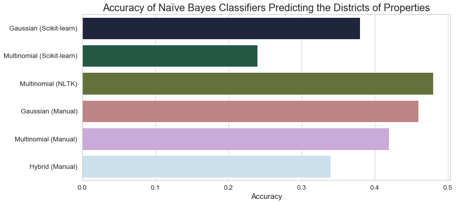

```python
# Display a bar plot of the classifier accuracies
sns.set(font_scale=1.2, style="whitegrid")
plt.figure(figsize=(13, 6))
ax = sns.barplot(x="Accuracies", y="Classifiers", data=experimental_data, palette="cubehelix")
ax.set_title("Accuracy of Naïve Bayes Classifiers Predicting the Districts of Properties", fontsize=20)
ax.set_xlabel("Accuracy", fontsize=15)
plt.show()
```

```python
print("{:<30} {}".format("Classifier", "Accuracy"))
print("{:<30} {}".format("----------", "--------"))
for i in range(len(accuracies)):
    print("{:<30} {:.3f}".format(classifiers[i], accuracies[i]))
```

```
Classifier                     Accuracy
----------                     --------
Gaussian (Scikit-learn)        0.380
Multinomial (Scikit-learn)     0.240
Multinomial (NLTK)             0.480
Gaussian (Manual)              0.460
Multinomial (Manual)           0.420
Hybrid (Manual)                0.340
```

#### 5.1.2. Accuracy of Classifiers as the Number of Attributes Increases

```python
# Determine the accuracies of each of the classifiers
gaussian_scikit_learn = []
multinomial_scikit_learn = []
multinomial_NLTK = []
gaussian_manual = []
multinomial_manual = []
hybrid_manual = []
num_classifiers = 6
num_attributes = [i+1 for i in range(len(attributes))] * num_classifiers

# Determine accuracies of the classifiers
for i in range(len(attributes)):

    # Create feature vectors consisting of i features
    x_train_mod = x_train[attributes[:i+1]]
    x_test_mod = x_test[attributes[:i+1]]
    x_train_manual_mod = x_train_mod.to_numpy()
    x_test_manual_mod = x_test_mod.to_numpy()
    xy_train_nltk_mod = [format_nltk_data_sample(x_train_manual_mod[j], y_train_manual[j], attributes) for j \
                 in range(len(y_train_manual))]
    x_test_nltk_mod = [format_nltk_data_sample(x_test_manual_mod[j], y_test_manual[j], attributes)[0] for j in \
                   range(len(y_test_manual))]
    y_test_nltk_mod = [format_nltk_data_sample(x_test_manual_mod[j], y_test_manual[j], attributes)[1] for j in \
                   range(len(y_test_manual))]

    # Scikit-learn Gaussian Naïve Bayes Classifier
    y_pred = scikit_learn_gaussian_NB(x_train_mod, y_train, x_test_mod)
    acc = metrics.accuracy_score(y_test, y_pred)
    gaussian_scikit_learn.append(acc)

    # Scikit-learn Multinomial Naïve Bayes Classifier
    y_pred = scikit_learn_multinomial_NB(x_train_mod, y_train, x_test_mod, laplace_smoothing=True)
    acc = metrics.accuracy_score(y_test, y_pred)
    multinomial_scikit_learn.append(acc)

    # NLTK Multinomial Naïve Bayes Classifier
    y_pred_nltk = NLTK_multinomial_NB(xy_train_nltk_mod, x_test_nltk_mod)
    acc = metrics.accuracy_score(y_test_nltk_mod, y_pred_nltk)
    multinomial_NLTK.append(acc)

    # Manually implemented Gaussian Naïve Bayes Classifier
    y_pred_m = manual_NB(x_train_manual_mod, y_train_manual, x_test_manual_mod, laplace_smoothing=False,
                         feature_assumption="gaussian")
    acc = metrics.accuracy_score(y_test_manual, y_pred_m)
    gaussian_manual.append(acc)

    # Manually implemented Categorical (Multinomial) Naïve Bayes Classifier
    y_pred_m = manual_NB(x_train_manual_mod, y_train_manual, x_test_manual_mod, laplace_smoothing=True,
                         feature_assumption="categorical")
    acc = metrics.accuracy_score(y_test_manual, y_pred_m)
    multinomial_manual.append(acc)

    # Manually implemented Hybrid (Multinomial/Gaussian) Naïve Bayes Classifier
    y_pred_m = manual_NB(x_train_manual_mod, y_train_manual, x_test_manual_mod, laplace_smoothing=True,
                         feature_assumption="hybrid")
    acc = metrics.accuracy_score(y_test_manual, y_pred_m)
    hybrid_manual.append(acc)
```

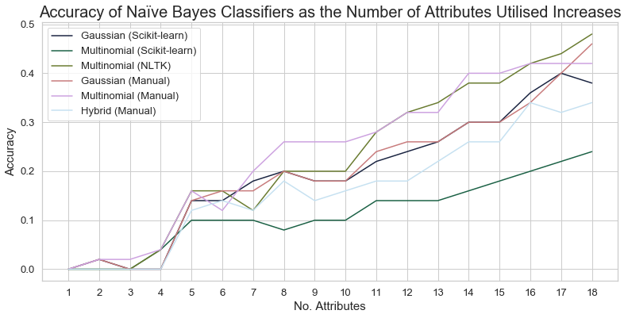

```python
# Create DataFrame of the experimental data
experimental_data = {"No. Attributes": num_attributes,
                     "Accuracy": gaussian_scikit_learn + multinomial_scikit_learn + multinomial_NLTK +\
                                 gaussian_manual + multinomial_manual + hybrid_manual,
                     "Classifier": np.ravel([[c] * len(attributes) for c in classifier_names])}

# Display a line plot of the classifier accuracies as the number of features increases
sns.set(font_scale=1.2, style="whitegrid")
plt.figure(figsize=(13, 6))
ax = sns.lineplot(x="No. Attributes", y="Accuracy", hue="Classifier", data=experimental_data, palette="cubehelix")
ax.set_title("Accuracy of Naïve Bayes Classifiers as the Number of Attributes Utilised Increases",
             fontsize=20)
ax.set_ylabel("Accuracy", fontsize=15)
ax.set_xlabel("No. Attributes", fontsize=15)
ax.set_xticks([i+1 for i in range(len(attributes))])
plt.show()
```

```python
print("{:<15} {}".format("Attribute No.", "Attribute Name"))
print("{:<15} {}".format("-------------", "--------------"))
for i in range(len(attributes)):
    print("{:<15} {}".format(i+1, attributes[i]))
```

```
Attribute No.   Attribute Name
-------------   --------------
1               state
2               full_sq
3               life_sq
4               floor
5               ecology
6               material
7               max_floor
8               build_year
9               product_type
10              nuclear_reactor_raion
11              thermal_power_plant_raion
12              incineration_raion
13              oil_chemistry_raion
14              radiation_raion
15              railroad_terminal_raion
16              big_market_raion
17              detention_facility_raion
18              railroad_1line
```

#### 5.2. Efficiency

#### 5.2.1. Time Efficiency of Classifiers on the Complete Test Set (All Selected Attributes)

```python
# Determine the time efficiency (time to construct and use the model) of each of the classifiers
durations = []
classifiers = []

# Scikit-learn Gaussian Naïve Bayes Classifier
start_time = time.clock()
y_pred = scikit_learn_gaussian_NB(x_train, y_train, x_test)
end_time = time.clock()
diff_time = end_time - start_time
durations.append(diff_time)
classifiers.append("Gaussian (Scikit-learn) ({:.2f}s)".format(diff_time))

# Scikit-learn Multinomial Naïve Bayes Classifier
start_time = time.clock()
y_pred = scikit_learn_multinomial_NB(x_train, y_train, x_test, laplace_smoothing=True)
end_time = time.clock()
diff_time = end_time - start_time
durations.append(diff_time)
classifiers.append("Multinomial (Scikit-learn) ({:.2f}s)".format(diff_time))

# NLTK Multinomial Naïve Bayes Classifier
start_time = time.clock()
y_pred_nltk = NLTK_multinomial_NB(xy_train_nltk, x_test_nltk)
end_time = time.clock()
diff_time = end_time - start_time
durations.append(diff_time)
classifiers.append("Multinomial (NLTK) ({:.2f}s)".format(diff_time))

# Manually implemented Gaussian Naïve Bayes Classifier
start_time = time.clock()
y_pred_m = manual_NB(x_train_manual, y_train_manual, x_test_manual, laplace_smoothing=False, feature_assumption="gaussian")
end_time = time.clock()
diff_time = end_time - start_time
durations.append(diff_time)
classifiers.append("Gaussian (Manual) ({:.2f}s)".format(diff_time))

# Manually implemented Categorical (Multinomial) Naïve Bayes Classifier
start_time = time.clock()
y_pred_m = manual_NB(x_train_manual, y_train_manual, x_test_manual, laplace_smoothing=True, feature_assumption="categorical")
end_time = time.clock()
diff_time = end_time - start_time
durations.append(diff_time)
classifiers.append("Multinomial (Manual) ({:.2f}s)".format(diff_time))

# Manually implemented Hybrid (Multinomial/Gaussian) Naïve Bayes Classifier
start_time = time.clock()
y_pred_m = manual_NB(x_train_manual, y_train_manual, x_test_manual, laplace_smoothing=True, feature_assumption="hybrid")
end_time = time.clock()
diff_time = end_time - start_time
durations.append(diff_time)
classifiers.append("Hybrid (Manual) ({:.2f}s)".format(diff_time))

# Create DataFrame of the experimental data
experimental_data = {"Classifiers": classifiers,
                     "Durations": durations}
```

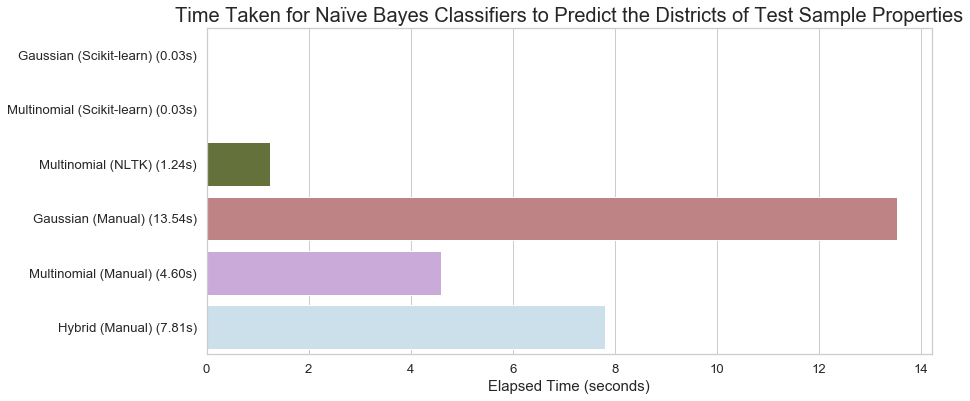

```python
# Display a bar plot of the classifier accuracies
sns.set(font_scale=1.2, style="whitegrid")
plt.figure(figsize=(13, 6))
ax = sns.barplot(x="Durations", y="Classifiers", data=experimental_data, palette="cubehelix")
ax.set_title("Time Taken for Naïve Bayes Classifiers to Predict the Districts of Test Sample Properties", fontsize=20)
ax.set_xlabel("Elapsed Time (seconds)", fontsize=15)
plt.show()
```

#### 5.3. Scalability

#### 5.3.1. Determine Scalability through Evaluating Efficiency when the Number of Attributes Increases

```python
# Determine the time efficiency (time to construct and use the model) of each of the classifiers
gaussian_scikit_learn = []
multinomial_scikit_learn = []
multinomial_NLTK = []
gaussian_manual = []
multinomial_manual = []
hybrid_manual = []
num_classifiers = 6
num_attributes = [i+1 for i in range(len(attributes))] * num_classifiers

# Determine the time efficiency of the classifiers
for i in range(len(attributes)):

    # Create feature vectors consisting of i features
    x_train_mod = x_train[attributes[:i+1]]
    x_test_mod = x_test[attributes[:i+1]]

    x_train_manual_mod = x_train_mod.to_numpy()
    x_test_manual_mod = x_test_mod.to_numpy()

    xy_train_nltk_mod = [format_nltk_data_sample(x_train_manual_mod[j], y_train_manual[j], attributes) for j \
                 in range(len(y_train_manual))]
    x_test_nltk_mod = [format_nltk_data_sample(x_test_manual_mod[j], y_test_manual[j], attributes)[0] for j in \
                   range(len(y_test_manual))]
    y_test_nltk_mod = [format_nltk_data_sample(x_test_manual_mod[j], y_test_manual[j], attributes)[1] for j in \
                   range(len(y_test_manual))]

    # Scikit-learn Gaussian Naïve Bayes Classifier
    start_time = time.clock()
    y_pred = scikit_learn_gaussian_NB(x_train_mod, y_train, x_test_mod)
    end_time = time.clock()
    diff_time = end_time - start_time
    gaussian_scikit_learn.append(diff_time)

    # Scikit-learn Multinomial Naïve Bayes Classifier
    start_time = time.clock()
    y_pred = scikit_learn_multinomial_NB(x_train_mod, y_train, x_test_mod, laplace_smoothing=True)
    end_time = time.clock()
    diff_time = end_time - start_time
    multinomial_scikit_learn.append(diff_time)

    # NLTK Multinomial Naïve Bayes Classifier
    start_time = time.clock()
    y_pred_nltk = NLTK_multinomial_NB(xy_train_nltk_mod, x_test_nltk_mod)
    end_time = time.clock()
    diff_time = end_time - start_time
    multinomial_NLTK.append(diff_time)

    # Manually implemented Gaussian Naïve Bayes Classifier
    start_time = time.clock()
    y_pred_m = manual_NB(x_train_manual_mod, y_train_manual, x_test_manual_mod, laplace_smoothing=False,
                         feature_assumption="gaussian")
    end_time = time.clock()
    diff_time = end_time - start_time
    gaussian_manual.append(diff_time)

    # Manually implemented Categorical (Multinomial) Naïve Bayes Classifier
    start_time = time.clock()
    y_pred_m = manual_NB(x_train_manual_mod, y_train_manual, x_test_manual_mod, laplace_smoothing=True,
                         feature_assumption="categorical")
    end_time = time.clock()
    diff_time = end_time - start_time
    multinomial_manual.append(diff_time)

    # Manually implemented Hybrid (Multinomial/Gaussian) Naïve Bayes Classifier
    start_time = time.clock()
    y_pred_m = manual_NB(x_train_manual_mod, y_train_manual, x_test_manual_mod, laplace_smoothing=True,
                         feature_assumption="hybrid")
    end_time = time.clock()
    diff_time = end_time - start_time
    hybrid_manual.append(diff_time)
```

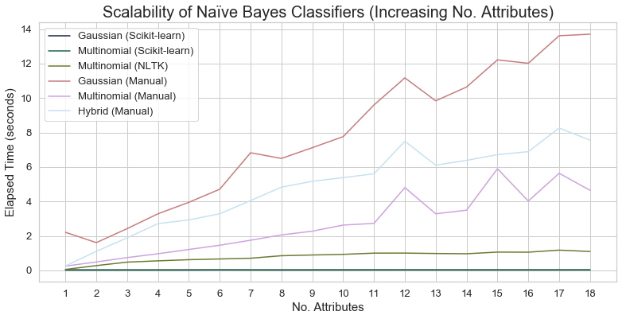

```python
# Create DataFrame of the experimental data
experimental_data = {"No. Attributes": num_attributes,
                     "Duration": gaussian_scikit_learn + multinomial_scikit_learn + multinomial_NLTK +\
                                 gaussian_manual + multinomial_manual + hybrid_manual,
                     "Classifier": np.ravel([[c] * len(attributes) for c in classifier_names])}

# Display a line plot of the efficiency of the classifier as the number of features increases
sns.set(font_scale=1.2, style="whitegrid")
plt.figure(figsize=(13, 6))
ax = sns.lineplot(x="No. Attributes", y="Duration", hue="Classifier", data=experimental_data, palette="cubehelix")
ax.set_title("Scalability of Naïve Bayes Classifiers (Increasing No. Attributes)",
             fontsize=20)
ax.set_ylabel("Elapsed Time (seconds)", fontsize=15)
ax.set_xlabel("No. Attributes", fontsize=15)
ax.set_xticks([i+1 for i in range(len(attributes))])
plt.legend(loc='upper left')
plt.show()
```

```python
print("{:<15} {}".format("Attribute No.", "Attribute Name"))
print("{:<15} {}".format("-------------", "--------------"))
for i in range(len(attributes)):
    print("{:<15} {}".format(i+1, attributes[i]))
```

```
Attribute No.   Attribute Name
-------------   --------------
1               state
2               full_sq
3               life_sq
4               floor
5               ecology
6               material
7               max_floor
8               build_year
9               product_type
10              nuclear_reactor_raion
11              thermal_power_plant_raion
12              incineration_raion
13              oil_chemistry_raion
14              radiation_raion
15              railroad_terminal_raion
16              big_market_raion
17              detention_facility_raion
18              railroad_1line
```

#### 5.3.2. Determine Scalability through Evaluating Efficiency when the Training Dataset Increases in Size

```python
# Determine the time efficiency (time to construct and use the model) of each of the classifiers
gaussian_scikit_learn = []
multinomial_scikit_learn = []
multinomial_NLTK = []
gaussian_manual = []
multinomial_manual = []
hybrid_manual = []
num_classifiers = 6
num_intervals = 10
interval_size = (len(x_train) - 8000) // num_intervals
intervals = [i for i in range(8000 + interval_size, len(x_train) + 1, interval_size)]
interval_sizes = intervals * num_classifiers

# Determine the time efficiency of the classifiers
for i in intervals:

    # Create datasets with i training data samples
    x_train_mod = x_train[:i]
    y_train_mod = y_train[:i]
    x_test_mod = x_test
    y_test_mod = y_test

    x_train_manual_mod = x_train_mod.to_numpy()
    y_train_manual_mod = y_train_mod.to_numpy().reshape(len(y_train_mod))
    x_test_manual_mod = x_test_mod.to_numpy()
    y_test_manual_mod = y_test_mod.to_numpy().reshape(len(y_test_mod))

    xy_train_nltk_mod = [format_nltk_data_sample(x_train_manual_mod[j], y_train_manual_mod[j], attributes) for j \
                 in range(len(y_train_manual_mod))]
    x_test_nltk_mod = [format_nltk_data_sample(x_test_manual_mod[j], y_test_manual_mod[j], attributes)[0] for j in \
                   range(len(y_test_manual_mod))]
    y_test_nltk_mod = [format_nltk_data_sample(x_test_manual_mod[j], y_test_manual_mod[j], attributes)[1] for j in \
                   range(len(y_test_manual_mod))]

    # Scikit-learn Gaussian Naïve Bayes Classifier
    start_time = time.clock()
    y_pred = scikit_learn_gaussian_NB(x_train_mod, y_train_mod, x_test_mod)
    end_time = time.clock()
    diff_time = end_time - start_time
    gaussian_scikit_learn.append(diff_time)

    # Scikit-learn Multinomial Naïve Bayes Classifier
    start_time = time.clock()
    y_pred = scikit_learn_multinomial_NB(x_train_mod, y_train_mod, x_test_mod, laplace_smoothing=True)
    end_time = time.clock()
    diff_time = end_time - start_time
    multinomial_scikit_learn.append(diff_time)

    # NLTK Multinomial Naïve Bayes Classifier
    start_time = time.clock()
    y_pred_nltk = NLTK_multinomial_NB(xy_train_nltk_mod, x_test_nltk_mod)
    end_time = time.clock()
    diff_time = end_time - start_time
    multinomial_NLTK.append(diff_time)

    # Manually implemented Gaussian Naïve Bayes Classifier
    start_time = time.clock()
    y_pred_m = manual_NB(x_train_manual_mod, y_train_manual_mod, x_test_manual_mod, laplace_smoothing=False,
                         feature_assumption="gaussian")
    end_time = time.clock()
    diff_time = end_time - start_time
    gaussian_manual.append(diff_time)

    # Manually implemented Categorical (Multinomial) Naïve Bayes Classifier
    start_time = time.clock()
    y_pred_m = manual_NB(x_train_manual_mod, y_train_manual_mod, x_test_manual_mod, laplace_smoothing=True,
                         feature_assumption="categorical")
    end_time = time.clock()
    diff_time = end_time - start_time
    multinomial_manual.append(diff_time)

    # Manually implemented Hybrid (Multinomial/Gaussian) Naïve Bayes Classifier
    start_time = time.clock()
    y_pred_m = manual_NB(x_train_manual_mod, y_train_manual_mod, x_test_manual_mod, laplace_smoothing=True,
                         feature_assumption="hybrid")
    end_time = time.clock()
    diff_time = end_time - start_time
    hybrid_manual.append(diff_time)
```

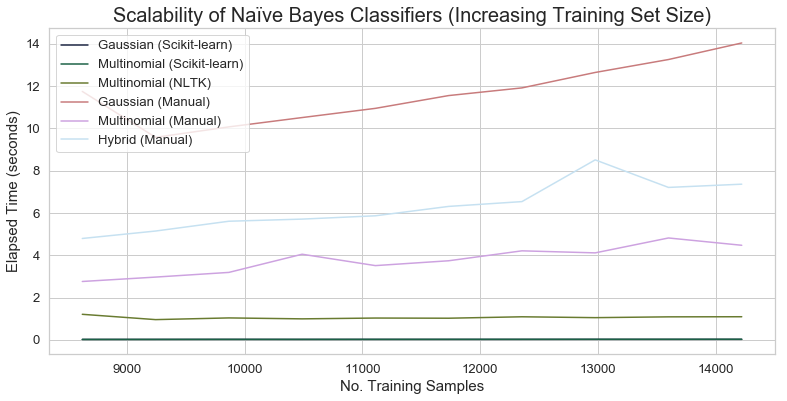

```python
# Create DataFrame of the experimental data
experimental_data = {"Training Set Size": interval_sizes,
                     "Duration": gaussian_scikit_learn + multinomial_scikit_learn + multinomial_NLTK +\
                                 gaussian_manual + multinomial_manual + hybrid_manual,
                     "Classifier": np.ravel([[c] * num_intervals for c in classifier_names])}

# Display a line plot of the efficiency of the classifier as the training set size increases
sns.set(font_scale=1.2, style="whitegrid")
plt.figure(figsize=(13, 6))
ax = sns.lineplot(x="Training Set Size", y="Duration", hue="Classifier", data=experimental_data, palette="cubehelix")
ax.set_title("Scalability of Naïve Bayes Classifiers (Increasing Training Set Size)",
             fontsize=20)
ax.set_ylabel("Elapsed Time (seconds)", fontsize=15)
ax.set_xlabel("No. Training Samples", fontsize=15)
plt.legend(loc='upper left')
plt.show()
```

#### 5.3.3. Determine Scalability through Evaluating Efficiency when the Test Dataset Increases in Size

```python
# Determine the time efficiency (time to construct and use the model) of each of the classifiers
gaussian_scikit_learn = []
multinomial_scikit_learn = []
multinomial_NLTK = []
gaussian_manual = []
multinomial_manual = []
hybrid_manual = []
num_classifiers = 6
num_intervals = 10
interval_size = len(x_test) // num_intervals
intervals = [i for i in range(interval_size, len(x_test) + 1, interval_size)]
interval_sizes = intervals * num_classifiers

# Determine the time efficiency of the classifiers
for i in intervals:

    # Create datasets with i test data samples
    x_train_mod = x_train
    y_train_mod = y_train
    x_test_mod = x_test[:i]
    y_test_mod = y_test[:i]

    x_train_manual_mod = x_train_mod.to_numpy()
    y_train_manual_mod = y_train_mod.to_numpy().reshape(len(y_train_mod))
    x_test_manual_mod = x_test_mod.to_numpy()
    y_test_manual_mod = y_test_mod.to_numpy().reshape(len(y_test_mod))

    xy_train_nltk_mod = [format_nltk_data_sample(x_train_manual_mod[j], y_train_manual_mod[j], attributes) for j \
                 in range(len(y_train_manual_mod))]
    x_test_nltk_mod = [format_nltk_data_sample(x_test_manual_mod[j], y_test_manual_mod[j], attributes)[0] for j in \
                   range(len(y_test_manual_mod))]
    y_test_nltk_mod = [format_nltk_data_sample(x_test_manual_mod[j], y_test_manual_mod[j], attributes)[1] for j in \
                   range(len(y_test_manual_mod))]

    # Scikit-learn Gaussian Naïve Bayes Classifier
    start_time = time.clock()
    y_pred = scikit_learn_gaussian_NB(x_train_mod, y_train_mod, x_test_mod)
    end_time = time.clock()
    diff_time = end_time - start_time
    gaussian_scikit_learn.append(diff_time)

    # Scikit-learn Multinomial Naïve Bayes Classifier
    start_time = time.clock()
    y_pred = scikit_learn_multinomial_NB(x_train_mod, y_train_mod, x_test_mod, laplace_smoothing=True)
    end_time = time.clock()
    diff_time = end_time - start_time
    multinomial_scikit_learn.append(diff_time)

    # NLTK Multinomial Naïve Bayes Classifier
    start_time = time.clock()
    y_pred_nltk = NLTK_multinomial_NB(xy_train_nltk_mod, x_test_nltk_mod)
    end_time = time.clock()
    diff_time = end_time - start_time
    multinomial_NLTK.append(diff_time)

    # Manually implemented Gaussian Naïve Bayes Classifier
    start_time = time.clock()
    y_pred_m = manual_NB(x_train_manual_mod, y_train_manual_mod, x_test_manual_mod, laplace_smoothing=False,
                         feature_assumption="gaussian")
    end_time = time.clock()
    diff_time = end_time - start_time
    gaussian_manual.append(diff_time)

    # Manually implemented Categorical (Multinomial) Naïve Bayes Classifier
    start_time = time.clock()
    y_pred_m = manual_NB(x_train_manual_mod, y_train_manual_mod, x_test_manual_mod, laplace_smoothing=True,
                         feature_assumption="categorical")
    end_time = time.clock()
    diff_time = end_time - start_time
    multinomial_manual.append(diff_time)

    # Manually implemented Hybrid (Multinomial/Gaussian) Naïve Bayes Classifier
    start_time = time.clock()
    y_pred_m = manual_NB(x_train_manual_mod, y_train_manual_mod, x_test_manual_mod, laplace_smoothing=True,
                         feature_assumption="hybrid")
    end_time = time.clock()
    diff_time = end_time - start_time
    hybrid_manual.append(diff_time)
```

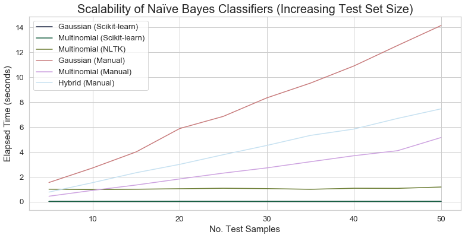

```python
# Create DataFrame of the experimental data
experimental_data = {"Test Set Size": interval_sizes,
                     "Duration": gaussian_scikit_learn + multinomial_scikit_learn + multinomial_NLTK +\
                                 gaussian_manual + multinomial_manual + hybrid_manual,
                     "Classifier": np.ravel([[c] * num_intervals for c in classifier_names])}

# Display a line plot of the efficiency of the classifier as the training set size increases
sns.set(font_scale=1.2, style="whitegrid")
plt.figure(figsize=(13, 6))
ax = sns.lineplot(x="Test Set Size", y="Duration", hue="Classifier", data=experimental_data, palette="cubehelix")
ax.set_title("Scalability of Naïve Bayes Classifiers (Increasing Test Set Size)",
             fontsize=20)
ax.set_ylabel("Elapsed Time (seconds)", fontsize=15)
ax.set_xlabel("No. Test Samples", fontsize=15)
plt.legend(loc='upper left')
plt.show()
```

#### 5.4. Precision and Recall

#### 5.4.1. Unweighted Average Precision of Classifiers on the Complete Test Set (All Selected Attributes)

```python
# Determine the unweighted average precision of each of the classifiers
avg_precisions = []
classifiers = []

# Scikit-learn Gaussian Naïve Bayes Classifier
y_pred = scikit_learn_gaussian_NB(x_train, y_train, x_test)
prec = metrics.precision_score(y_test, y_pred, average="macro")
classifiers.append("Gaussian (Scikit-learn)")
avg_precisions.append(prec)

# Scikit-learn Multinomial Naïve Bayes Classifier
y_pred = scikit_learn_multinomial_NB(x_train, y_train, x_test, laplace_smoothing=True)
prec = metrics.precision_score(y_test, y_pred, average="macro")
classifiers.append("Multinomial (Scikit-learn)")
avg_precisions.append(prec)

# NLTK Multinomial Naïve Bayes Classifier
y_pred_nltk = NLTK_multinomial_NB(xy_train_nltk, x_test_nltk)
prec = metrics.precision_score(y_test_nltk, y_pred_nltk, average="macro")
classifiers.append("Multinomial (NLTK)")
avg_precisions.append(prec)

# Manually implemented Gaussian Naïve Bayes Classifier
y_pred_m = manual_NB(x_train_manual, y_train_manual, x_test_manual, laplace_smoothing=False, feature_assumption="gaussian")
prec = metrics.precision_score(y_test_manual, y_pred_m, average="macro")
classifiers.append("Gaussian (Manual)")
avg_precisions.append(prec)

# Manually implemented Categorical (Multinomial) Naïve Bayes Classifier
y_pred_m = manual_NB(x_train_manual, y_train_manual, x_test_manual, laplace_smoothing=True, feature_assumption="categorical")
prec = metrics.precision_score(y_test_manual, y_pred_m, average="macro")
classifiers.append("Multinomial (Manual)")
avg_precisions.append(prec)

# Manually implemented Hybrid (Multinomial/Gaussian) Naïve Bayes Classifier
y_pred_m = manual_NB(x_train_manual, y_train_manual, x_test_manual, laplace_smoothing=True, feature_assumption="hybrid")
prec = metrics.precision_score(y_test_manual, y_pred_m, average="macro")
classifiers.append("Hybrid (Manual)")
avg_precisions.append(prec)

# Create DataFrame of the experimental data
experimental_data = {"Classifiers": classifiers,
                     "Average Precisions": avg_precisions}
```

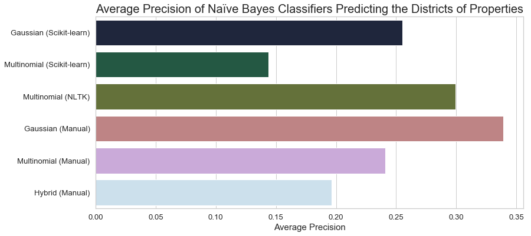

```python
# Display a bar plot of the classifier average precisions
sns.set(font_scale=1.2, style="whitegrid")
plt.figure(figsize=(13, 6))
ax = sns.barplot(x="Average Precisions", y="Classifiers", data=experimental_data, palette="cubehelix")
ax.set_title("Average Precision of Naïve Bayes Classifiers Predicting the Districts of Properties", fontsize=20)
ax.set_xlabel("Average Precision", fontsize=15)
plt.show()
```

```python
print("{:<30} {}".format("Classifier", "Avg. Precision"))
print("{:<30} {}".format("----------", "--------"))
for i in range(len(avg_precisions)):
    print("{:<30} {:.3f}".format(classifiers[i], avg_precisions[i]))
```

```
Classifier                     Avg. Precision
----------                     --------
Gaussian (Scikit-learn)        0.255
Multinomial (Scikit-learn)     0.144
Multinomial (NLTK)             0.299
Gaussian (Manual)              0.339
Multinomial (Manual)           0.241
Hybrid (Manual)                0.197
```

#### 5.4.2. Unweighted Average Recall of Classifiers on the Complete Test Set (All Selected Attributes)

```python
# Determine the unweighted average recall of each of the classifiers
avg_recalls = []
classifiers = []

# Scikit-learn Gaussian Naïve Bayes Classifier
y_pred = scikit_learn_gaussian_NB(x_train, y_train, x_test)
rec = metrics.recall_score(y_test, y_pred, average="macro")
classifiers.append("Gaussian (Scikit-learn)")
avg_recalls.append(rec)

# Scikit-learn Multinomial Naïve Bayes Classifier
y_pred = scikit_learn_multinomial_NB(x_train, y_train, x_test, laplace_smoothing=True)
rec = metrics.recall_score(y_test, y_pred, average="macro")
classifiers.append("Multinomial (Scikit-learn)")
avg_recalls.append(rec)

# NLTK Multinomial Naïve Bayes Classifier
y_pred_nltk = NLTK_multinomial_NB(xy_train_nltk, x_test_nltk)
rec = metrics.recall_score(y_test_nltk, y_pred_nltk, average="macro")
classifiers.append("Multinomial (NLTK)")
avg_recalls.append(rec)

# Manually implemented Gaussian Naïve Bayes Classifier
y_pred_m = manual_NB(x_train_manual, y_train_manual, x_test_manual, laplace_smoothing=False, feature_assumption="gaussian")
rec = metrics.recall_score(y_test_manual, y_pred_m, average="macro")
classifiers.append("Gaussian (Manual)")
avg_recalls.append(rec)

# Manually implemented Categorical (Multinomial) Naïve Bayes Classifier
y_pred_m = manual_NB(x_train_manual, y_train_manual, x_test_manual, laplace_smoothing=True, feature_assumption="categorical")
rec = metrics.recall_score(y_test_manual, y_pred_m, average="macro")
classifiers.append("Multinomial (Manual)")
avg_recalls.append(rec)

# Manually implemented Hybrid (Multinomial/Gaussian) Naïve Bayes Classifier
y_pred_m = manual_NB(x_train_manual, y_train_manual, x_test_manual, laplace_smoothing=True, feature_assumption="hybrid")
rec = metrics.recall_score(y_test_manual, y_pred_m, average="macro")
classifiers.append("Hybrid (Manual)")
avg_recalls.append(rec)

# Create DataFrame of the experimental data
experimental_data = {"Classifiers": classifiers,
                     "Average Recalls": avg_recalls}
```

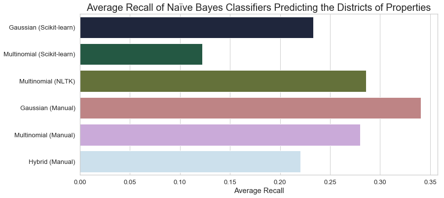

```python
# Display a bar plot of the classifier average precisions
sns.set(font_scale=1.2, style="whitegrid")
plt.figure(figsize=(13, 6))
ax = sns.barplot(x="Average Recalls", y="Classifiers", data=experimental_data, palette="cubehelix")
ax.set_title("Average Recall of Naïve Bayes Classifiers Predicting the Districts of Properties", fontsize=20)
ax.set_xlabel("Average Recall", fontsize=15)
plt.show()
```

```python
print("{:<30} {}".format("Classifier", "Avg. Recall"))
print("{:<30} {}".format("----------", "--------"))
for i in range(len(avg_recalls)):
    print("{:<30} {:.3f}".format(classifiers[i], avg_recalls[i]))
```

```
Classifier                     Avg. Recall
----------                     --------
Gaussian (Scikit-learn)        0.233
Multinomial (Scikit-learn)     0.122
Multinomial (NLTK)             0.286
Gaussian (Manual)              0.341
Multinomial (Manual)           0.280
Hybrid (Manual)                0.220
```

#### 5.5. Predicting Russian Districts based upon Information about the Property and the Surrounding Area

Here we explore a potential use case for the Naïve Bayes Classifier within the domain of the Russian housing market. Essentially, the Naïve Bayes Classifier allows us to determine the most probable district given certain information about a property and the surrounding area. With such an algorithm, home buyers could find districts with certain property and neighbourhood characteristics that are ideal for themselves and/or their families. Moreover, businesses could also use this algorithm to determine where to build their next office or start their next advertisement campaign. As a result of this practical potential, we decided to implement an algorithm that predicts the districts of properties given some information about the properties and the surrounding area.

For the implementation of the algorithm, we decided to use the Gaussian Naïve Bayes Classifier. When a user would like to find out the most probable district given certain characteristics, we will collect their specified property and surrounding area characteristics and add them to a feature vector that can be given to the Gaussian Naïve Bayes Classifier. For the attributes that were not specified by the user, we will calculate their mode from the training set and use those values for the remaining elements of the feature vector (we use mode here since some categorical attributes in the training set are encoded as a discrete set of integers, thus the mean of an attribute may not be a real value for that attribute). We can then simply use the Gaussian Naïve Bayes Classifier to calculate the most probable districts for the given feature vector and report to the user the predicted districts based upon the property and surrounding area characteristics they specified.

Note that the manual implementation of the Gaussian Naïve Bayes Classifier was used in the district predictor algorithm.

```python
class DistrictPredictor:
    """ Property District Predictor for the Russian Housing Market."""

    def __init__(self, x_train, y_train):
        """ Initialises variables for the PropertyPricePredictor class.

        :param x_train: Two dimensional array containing the training set feature vectors.
        :param y_train: One dimensional array containing the training set target values.
        :var x_train_mode: One dimensional array containing the training set feature vector attribute modes.
        :var nbc: A ManualNB class object representing a Naïve Bayes Classifier.
        """

        # Calculate the mode for each of the input vector attributes in the training set
        self.x_train_mode = stats.mode(x_train, axis=0)[0][0]

        # Define hyperparameters for the Naïve Bayes Classifier.
        laplace_smoothing = True
        feature_assumption = "gaussian"

        # Create a Manually implemented Naïve Bayes Classifier
        self.nbc = ManualNB(laplace_smoothing=laplace_smoothing, feature_assumption=feature_assumption)

        # Train the model on the training set
        self.nbc.fit(x_train, y_train)

    def predict_district(self, characteristics_dict, top_n=3, preprocess=True):
        """ Accepts the user input property and surrounding area characteristics and returns the predicted property districts.

        :param characteristics_dict: A dictionary mapping "attribute name" to "specified value" for each of the user
                                     input property and surrounding area characteristics. For example:
                                     {"floor": 1, "max_floor": 5, "nuclear_reactor_raion": "no"}
        :param top_n: An integer specifying the number of top predicted districts to return.
        :param preprocess: A Boolean value specifying whether or not the characteristics_dict needs to be preprocessed or not.
        :return: The top_n most probable districts for the given property and surrounding area characteristics.
        """

        # Define input feature vector
        feature_vector = self.x_train_mode.copy()

        # Preprocess the user input property and surrounding area values
        for a in characteristics_dict.keys():
            value = characteristics_dict[a]

            if preprocess:

                # Perform Data Transformation and Data Discretization
                if a in attribute_encoders.keys():
                    value = attribute_encoders[a].transform(np.array([value]))
                    value = value[0]

            # Add value to the input feature vector
            feature_vector[attributes.index(a)] = value

        # Predict the property district based upon property and neighbourhood attributes
        y_pred_prob = self.nbc.predict(np.array([feature_vector]), prob=True)[0]

        # Find the top n predicted class label probabilities
        top_prob = sorted(y_pred_prob, reverse=True)[:top_n]

        # Determine what the top n predicted districts were for the property and neighbourhood attributes
        top_districts = [y_pred_prob.index(p) for p in top_prob]

        # Return predicted districts
        return top_districts
```

```python
# Create a DistrictPredictor class object
predictor = DistrictPredictor(x_train_manual, y_train_manual)
```

#### 5.5.1. Algorithm Use Cases

Example attribute values to use:

```
|---------------------------------------------------------------------------------------------------------|
| Attribute             | Description                                   | Value Range                     |
|---------------------------------------------------------------------------------------------------------|
| full_sq               | total area in square meters                   | [1.0, 7478.0]                   |
| life_sq               | living area in square meters                  | [0, 7478.0]                     |
| floor                 | for apartments, floor of the building         | [0, 77]                         |
| max_floor             | number of floors in the building              | [0, 77]                         |
| build_year            | year built                                    | [1860, 2018]                    |
| big_market_raion      | presence of large grocery / wholesale markets | {"Yes", "No"}                   |
| product_type          | owner-occupier purchase or investment         | {"OwnerOccupier", "Investment"} |
| nuclear_reactor_raion | presence of existing nuclear reactors         | {"Yes", "No"}                   |
|---------------------------------------------------------------------------------------------------------|
```

```python
def district_predictor(predictor, input_dict):

    # Predict property district given the provided characteristics
    predicted_districts = predictor.predict_district(input_dict)

    # Display output to the user
    print("Districts with property and neighbourhood characteristics most similar to those you specified:")
    for i, d in enumerate(predicted_districts):
        d = attribute_encoders["sub_area"].inverse_transform(np.array([d]))
        d = d[0]
        print("  {}. {}".format(i+1, d))
```

```python
# Example use case 1
district_predictor(predictor, {"full_sq": 100, "life_sq": 50, "floor": 1})
```

```
Districts with property and neighbourhood characteristics most similar to those you specified:
  1. Juzhnoe Butovo
  2. Horoshevskoe
  3. Hovrino
```

```python
# Example use case 2
district_predictor(predictor, {"life_sq": 50, "build_year": 2000, "railroad_terminal_raion": "yes"})
```

```
Districts with property and neighbourhood characteristics most similar to those you specified:
  1. Mar'ina Roshha
  2. Butyrskoe
  3. Krasnosel'skoe
```

```python
# Example use case 3
district_predictor(predictor, {"life_sq": 100, "build_year": 2000, "railroad_terminal_raion": "yes"})
```

```
Districts with property and neighbourhood characteristics most similar to those you specified:
  1. Krasnosel'skoe
  2. Mar'ina Roshha
  3. Butyrskoe
```

```python
# Example use case 4
district_predictor(predictor, {"state": 3, "floor": 50, "ecology": "good", "material": 3, "build_year": 1980})
```

```
Districts with property and neighbourhood characteristics most similar to those you specified:
  1. Mitino
  2. Nagornoe
  3. Solncevo
```

#### 5.5.2. Convergence Towards Actual District

```python
# Select a test sample (interesting samples: 7, 11, 30)
index = 11
y_sample = y_test_manual[index]
x_sample = x_test_manual[index]

# Collect district predictions from the DistrictPredictor as the number of true attribute values increases
top_n = 3
district_predictions = [[] for i in range(top_n)]
for i in range(len(attributes) + 1):

    # Create input dictionary
    input_dict = {}
    for j in range(i):
        input_dict[attributes[j]] = x_sample[j]

    # Predict property district
    predicted_district = predictor.predict_district(input_dict, top_n=top_n, preprocess=False)
    for i, p in enumerate(predicted_district):
        district_predictions[i].append(p)
```

```python
# Prepare experimental data for creating the graph
identifiers = ["Prediction Rank {}".format(i+1) for i in range(top_n)]
identifiers.append("Actual")
district_predictions.append([y_sample for i in range(len(attributes) + 1)])
```

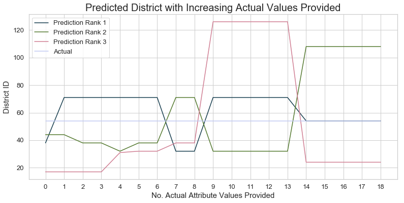

```python
# Create DataFrame of the experimental data
experimental_data = {"No. Actual Attribute Values": [i for i in range(len(attributes) + 1)] * (top_n + 1),
                     "District": np.ravel(district_predictions),
                     "Identifier": np.ravel([[n] * (len(attributes) + 1) for n in identifiers])}

# Display a line plot of the DistrictPredictor property district predictions as the number of actual attribute values
# provided increases
sns.set(font_scale=1.2, style="whitegrid")
plt.figure(figsize=(13, 6))
ax = sns.lineplot(x="No. Actual Attribute Values", y="District", hue="Identifier", data=experimental_data,
                  palette="cubehelix")
ax.set_title("Predicted District with Increasing Actual Values Provided", fontsize=20)
ax.set_ylabel("District ID", fontsize=15)
ax.set_xlabel("No. Actual Attribute Values Provided", fontsize=15)
ax.set_xticks([i for i in range(len(attributes) + 1)])
plt.show()
```